# Practical Machine Learning Project

Nicolás Huertas

6/5/2017

## Purpose

The intention of this project is to generate a predicting model algorithm that is able to classify how the person perform the excercise from 5 different possible ways A, B, C, D, and E for this we have a training data set available [here](https://d396qusza40orc.cloudfront.net/predmachlearn/pml-training.csv) and a test data set available [here](https://d396qusza40orc.cloudfront.net/predmachlearn/pml-testing.csv) there is also more information about the project [here](http://groupware.les.inf.puc-rio.br/har.)

## Data cleaning

So first we observe thatt the training set has 160 variables, that mean 159 predictors for the variable classe, the training set has 19622 observations. while the test set has 160 and 20 now we proceed to change the data sets We are going to get the data only from the sensors and instead of imputing the data due to the missing values are all missing the missing values will be removed the variables we are going to use are shown below

```r
filter <- grep("belt|forearm|arm|dumbbell", names(training))
training <- training[, filter]
testing <- testing[, filter]
nafilter <- colSums(is.na(training)) == 0
training <- training[, nafilter]
testing <- testing[, nafilter]
filter <- grep("kurtosis|skewness", names(training))
training <- training[, -filter]
testing <- testing[, -filter]
names(training)
```

```
##  [1] "roll_belt"              "pitch_belt"
##  [3] "yaw_belt"               "total_accel_belt"
##  [5] "max_yaw_belt"           "min_yaw_belt"
##  [7] "amplitude_yaw_belt"     "gyros_belt_x"
##  [9] "gyros_belt_y"           "gyros_belt_z"
## [11] "accel_belt_x"           "accel_belt_y"
## [13] "accel_belt_z"           "magnet_belt_x"
## [15] "magnet_belt_y"          "magnet_belt_z"
## [17] "roll_arm"               "pitch_arm"
## [19] "yaw_arm"                "total_accel_arm"
## [21] "gyros_arm_x"            "gyros_arm_y"
## [23] "gyros_arm_z"            "accel_arm_x"
## [25] "accel_arm_y"            "accel_arm_z"
## [27] "magnet_arm_x"           "magnet_arm_y"
## [29] "magnet_arm_z"           "roll_dumbbell"
```

[output cut: 16 more lines]

## Exploratory data analysis

First we evaluate if there variables with almost zero variance and are not good

```r
zero.var = nearZeroVar(training, saveMetrics = TRUE)
zero.var
```

```
##                         freqRatio percentUnique zeroVar   nzv
## roll_belt                1.101904    6.77810621   FALSE FALSE
## pitch_belt               1.036082    9.37722964   FALSE FALSE
## yaw_belt                 1.058480    9.97349913   FALSE FALSE
## total_accel_belt         1.063160    0.14779329   FALSE FALSE
## max_yaw_belt           640.533333    0.34654979   FALSE  TRUE
## min_yaw_belt           640.533333    0.34654979   FALSE  TRUE
## amplitude_yaw_belt      50.041667    0.02038528   FALSE  TRUE
## gyros_belt_x             1.058651    0.71348486   FALSE FALSE
## gyros_belt_y             1.144000    0.35164611   FALSE FALSE
## gyros_belt_z             1.066214    0.86127816   FALSE FALSE
## accel_belt_x             1.055412    0.83579655   FALSE FALSE
## accel_belt_y             1.113725    0.72877383   FALSE FALSE
## accel_belt_z             1.078767    1.52379982   FALSE FALSE
## magnet_belt_x            1.090141    1.66649679   FALSE FALSE
## magnet_belt_y            1.099688    1.51870350   FALSE FALSE
## magnet_belt_z            1.006369    2.32901845   FALSE FALSE
## roll_arm                52.338462   13.52563449   FALSE FALSE
## pitch_arm               87.256410   15.73234125   FALSE FALSE
## yaw_arm                 33.029126   14.65701763   FALSE FALSE
## total_accel_arm          1.024526    0.33635715   FALSE FALSE
## gyros_arm_x              1.015504    3.27693405   FALSE FALSE
## gyros_arm_y              1.454369    1.91621649   FALSE FALSE
## gyros_arm_z              1.110687    1.26388747   FALSE FALSE
## accel_arm_x              1.017341    3.95984099   FALSE FALSE
## accel_arm_y              1.140187    2.73672409   FALSE FALSE
## accel_arm_z              1.128000    4.03628580   FALSE FALSE
## magnet_arm_x             1.000000    6.82397309   FALSE FALSE
## magnet_arm_y             1.056818    4.44399144   FALSE FALSE
## magnet_arm_z             1.036364    6.44684538   FALSE FALSE
## roll_dumbbell            1.022388   84.20650290   FALSE FALSE
## pitch_dumbbell           2.277372   81.74498012   FALSE FALSE
## yaw_dumbbell             1.132231   83.48282540   FALSE FALSE
## max_yaw_dumbbell       960.800000    0.37203139   FALSE  TRUE
## min_yaw_dumbbell       960.800000    0.37203139   FALSE  TRUE
## amplitude_yaw_dumbbell  47.920200    0.01528896   FALSE  TRUE
## total_accel_dumbbell     1.072634    0.21914178   FALSE FALSE
## gyros_dumbbell_x         1.003268    1.22821323   FALSE FALSE
## gyros_dumbbell_y         1.264957    1.41677709   FALSE FALSE
## gyros_dumbbell_z         1.060100    1.04984201   FALSE FALSE
## accel_dumbbell_x         1.018018    2.16593619   FALSE FALSE
## accel_dumbbell_y         1.053061    2.37488533   FALSE FALSE
## accel_dumbbell_z         1.133333    2.08949139   FALSE FALSE
## magnet_dumbbell_x        1.098266    5.74864948   FALSE FALSE
## magnet_dumbbell_y        1.197740    4.30129447   FALSE FALSE
## magnet_dumbbell_z        1.020833    3.44511263   FALSE FALSE
## roll_forearm            11.589286   11.08959331   FALSE FALSE
## pitch_forearm           65.983051   14.85577413   FALSE FALSE
## yaw_forearm             15.322835   10.14677403   FALSE FALSE
## max_yaw_forearm        228.761905    0.22933442   FALSE  TRUE
## min_yaw_forearm        228.761905    0.22933442   FALSE  TRUE
## amplitude_yaw_forearm   59.677019    0.01528896   FALSE  TRUE
## total_accel_forearm      1.128928    0.35674243   FALSE FALSE
## gyros_forearm_x          1.059273    1.51870350   FALSE FALSE
## gyros_forearm_y          1.036554    3.77637346   FALSE FALSE
## gyros_forearm_z          1.122917    1.56457038   FALSE FALSE
## accel_forearm_x          1.126437    4.04647844   FALSE FALSE
## accel_forearm_y          1.059406    5.11160942   FALSE FALSE
## accel_forearm_z          1.006250    2.95586586   FALSE FALSE
## magnet_forearm_x         1.012346    7.76679238   FALSE FALSE
## magnet_forearm_y         1.246914    9.54031189   FALSE FALSE
## magnet_forearm_z         1.000000    8.57710733   FALSE FALSE
```

as observe in the analysis there are a couple of predictors that have almost zero variance so they will be excluded from the analysis

```r
filter <- grep("max|min|amplitude", names(training))
training <- training[, -filter]
testing <- testing[, -filter]
names(training)
```

```
##  [1] "roll_belt"            "pitch_belt"           "yaw_belt"
##  [4] "total_accel_belt"     "gyros_belt_x"         "gyros_belt_y"
##  [7] "gyros_belt_z"         "accel_belt_x"         "accel_belt_y"
## [10] "accel_belt_z"         "magnet_belt_x"        "magnet_belt_y"
## [13] "magnet_belt_z"        "roll_arm"             "pitch_arm"
## [16] "yaw_arm"              "total_accel_arm"      "gyros_arm_x"
## [19] "gyros_arm_y"          "gyros_arm_z"          "accel_arm_x"
## [22] "accel_arm_y"          "accel_arm_z"          "magnet_arm_x"
## [25] "magnet_arm_y"         "magnet_arm_z"         "roll_dumbbell"
## [28] "pitch_dumbbell"       "yaw_dumbbell"         "total_accel_dumbbell"
## [31] "gyros_dumbbell_x"     "gyros_dumbbell_y"     "gyros_dumbbell_z"
## [34] "accel_dumbbell_x"     "accel_dumbbell_y"     "accel_dumbbell_z"
## [37] "magnet_dumbbell_x"    "magnet_dumbbell_y"    "magnet_dumbbell_z"
## [40] "roll_forearm"         "pitch_forearm"        "yaw_forearm"
## [43] "total_accel_forearm"  "gyros_forearm_x"      "gyros_forearm_y"
## [46] "gyros_forearm_z"      "accel_forearm_x"      "accel_forearm_y"
## [49] "accel_forearm_z"      "magnet_forearm_x"     "magnet_forearm_y"
## [52] "magnet_forearm_z"
```

Now we proceed to plot the outcome classe vs some of the predictors

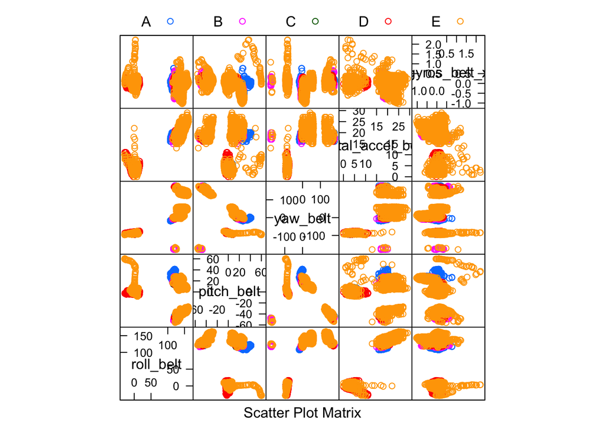

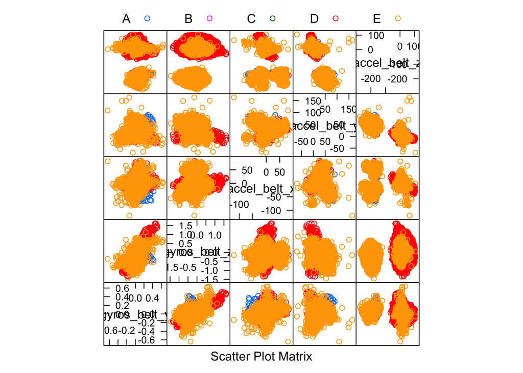

There is no clear pattern according to this graphs to generate a simple logistic regression no further plota here made due to computational time taken

## Model creation

1. **Reproductibility**

```r
training<-cbind(training,classe)
set.seed(12345)
inTraining <- createDataPartition(training$classe, p = .75, list=FALSE)
trainingSub <- training[inTraining,]
testingSub <- training[-inTraining,]
```

*to be able to evaluate the results we re partinioned the data into tsest and train*

2. **Cross Validation**

```r
fitControl <- trainControl(method = "cv",
                           number = 10,
                           allowParallel = TRUE)
```

*this is the cros validation configuration that is going to be used*

3. **Accuracy**

```r
y<-testingSub[,53]
x<-testingSub[,-53]
p<-predict(randomFmodel,x)
confusionMatrix(p,y)
```

```
## Confusion Matrix and Statistics
##
##           Reference
## Prediction    A    B    C    D    E
##          A 1395    9    0    0    0
##          B    0  938    3    0    0
##          C    0    2  852   10    1
##          D    0    0    0  794    4
##          E    0    0    0    0  896
##
## Overall Statistics
##
##                Accuracy : 0.9941
##                  95% CI : (0.9915, 0.996)
##     No Information Rate : 0.2845
##     P-Value [Acc > NIR] : < 2.2e-16
##
##                   Kappa : 0.9925
##  Mcnemar's Test P-Value : NA
##
## Statistics by Class:
##
##                      Class: A Class: B Class: C Class: D Class: E
## Sensitivity            1.0000   0.9884   0.9965   0.9876   0.9945
## Specificity            0.9974   0.9992   0.9968   0.9990   1.0000
## Pos Pred Value         0.9936   0.9968   0.9850   0.9950   1.0000
## Neg Pred Value         1.0000   0.9972   0.9993   0.9976   0.9988
## Prevalence             0.2845   0.1935   0.1743   0.1639   0.1837
## Detection Rate         0.2845   0.1913   0.1737   0.1619   0.1827
## Detection Prevalence   0.2863   0.1919   0.1764   0.1627   0.1827
## Balanced Accuracy      0.9987   0.9938   0.9966   0.9933   0.9972
```

As we observe the accuracy is 99% ** we expect the put of sample error to be a litlle higher**

4. **QUIZ**

```r
x<-testing
p<-predict(randomFmodel,x)
p
```

*Reulst not showed due to HONOR CODE*

## Conclusions

Now we can classify the way a person is performing the activity with a 99% accuracy more or less to do this we cleaned the data set we were given eliminating missing values and finding variables that had almost zero variance next we tried to visualize the data to find patterns, no patterns were found so we proceed to elaborate a **Random Forest** model that has the capability of classificating the type of exercise into the five categories A, B, C, D ,E